# Contrast stretching for a Sentinel-2 scene

## Finding a scene

First we write a quick plot to find the MGRS code at (bottom left corner of) the tile we want.

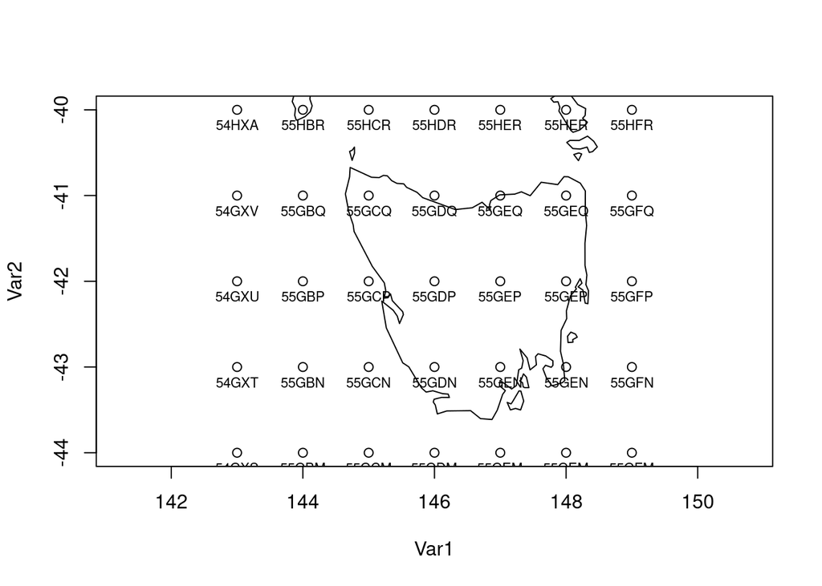

```r
p <- expand.grid(143:149, -44:-40)
plot(p, asp = 1/cos(-40 * pi/180))
maps::map(add = TRUE)
text(p, lab = geographiclib::mgrs_fwd(as.matrix(p) * 1.0, precision = 0), pos = 1, cex = .7)
```

Then look up a scene for that tile on a date we already know has one.

```r
## remotes::install_github("hypertidy/sds")
qu <- sds::stacit(c("55GDN"), "2026-02-27")
## get the STAC monstrosity and find the href:
js <- jsonlite::fromJSON(qu)
sprintf("/vsicurl/%s", js$features$assets$red$href)
```

```
[1] "/vsicurl/https://e84-earth-search-sentinel-data.s3.us-west-2.amazonaws.com/sentinel-2-c1-l2a/55/G/DN/2026/2/S2C_T55GDN_20260227T000650_L2A/B04.tif"
```

## Stretch functions

All functions return values in **[0, 1]**. Named with the `s2_` prefix to avoid clashing with `terra::stretch()`.

```r
library(terra)
# 1. Linear percent clip
# low/high are the natural UX knobs; 2%/98% is a solid default,
# tighter for low-contrast scenes.
s2_stretch_linear <- function(x, low = 0.02, high = 0.98) {
  v  <- terra::values(x, na.rm = TRUE)
  lo <- quantile(v, low,  na.rm = TRUE)
  hi <- quantile(v, high, na.rm = TRUE)
  terra::clamp(x, lo, hi, values = TRUE) |>
    (\(r) (r - lo) / (hi - lo))()
}

# 2. Log stretch (per-band minimum offset, guards log(0))
# Use only on integer overview values, not native-res reflectance — see gotcha below.
s2_stretch_log <- function(x, offset = NULL) {
  if (is.null(offset)) {
    mn     <- min(terra::global(x, "min", na.rm = TRUE)[[1]])
    offset <- if (mn <= 0) abs(mn) + 1 else 0
  }
  log1p(x + offset) |> s2_stretch_linear()
}

# 3. Log-relative: subtract global minimum before log.
# + 1 guards against log(0) when a pixel equals the minimum exactly.
s2_stretch_log_relative <- function(x, low = 0.02, high = 0.98) {
  mn <- min(terra::global(x, "min", na.rm = TRUE)[[1]])
  log(x - mn + 1) |> s2_stretch_linear(low, high)
}

# Joint variant: single global minimum AND a single quantile clip across all
# bands combined — preserves inter-band luminance relationships for true-colour RGB.
# In practice the visual difference from per-band is subtle for well-exposed scenes;
# the real fix for colour balance is the shared minimum subtraction.
s2_stretch_log_relative_joint <- function(x, low = 0.02, high = 0.98) {
  mn     <- min(terra::global(x, "min", na.rm = TRUE)[[1]])
  logged <- log(x - mn + 1)
  v      <- as.vector(terra::values(logged, na.rm = TRUE))  # flatten all bands
  lo     <- quantile(v, low,  na.rm = TRUE)
  hi     <- quantile(v, high, na.rm = TRUE)
  terra::clamp(logged, lo, hi, values = TRUE) |>
    (\(r) (r - lo) / (hi - lo))()
}

# 4. Square root — gentler than log, good middle ground.
s2_stretch_sqrt <- function(x) {
  mn     <- min(terra::global(x, "min", na.rm = TRUE)[[1]])
  offset <- if (mn < 0) abs(mn) else 0
  sqrt(x + offset) |> s2_stretch_linear()
}

# 5. Histogram equalisation.
# Good when interesting detail spans simultaneously deep shadow and bright areas.
s2_stretch_histeq <- function(x, n = 256) {
  v      <- terra::values(x, na.rm = TRUE)
  breaks <- quantile(v, probs = seq(0, 1, length.out = n + 1), na.rm = TRUE)
  out    <- x
  terra::values(out) <- findInterval(terra::values(x), unique(breaks)) /
                         length(unique(breaks))
  out
}
```

### Dispatcher

`joint` defaults to `TRUE` for multi-band input so that RGB composites share a common stretch across all three channels.

```r
s2_stretch <- function(x,
                       method = c("linear", "log", "sqrt", "histeq", "log_relative"),
                       low = 0.02, high = 0.98,
                       joint = terra::nlyr(x) > 1, ...) {
  method <- match.arg(method)
  switch(method,
    linear = if (joint) {
               v  <- terra::values(x, na.rm = TRUE)
               lo <- quantile(v, low,  na.rm = TRUE)
               hi <- quantile(v, high, na.rm = TRUE)
               terra::clamp(x, lo, hi, values = TRUE) |>
                 (\(r) (r - lo) / (hi - lo))()
             } else s2_stretch_linear(x, low, high),
    log_relative = if (joint) s2_stretch_log_relative_joint(x, low, high)
                   else       s2_stretch_log_relative(x, low, high),
    log    = s2_stretch_log(x, ...),
    sqrt   = s2_stretch_sqrt(x),
    histeq = s2_stretch_histeq(x, ...)
  )
}

# terra::plotRGB() requires [0, 255]; terra::stretch() is used solely for that
# byte-scaling side effect, applied to already-stretched [0, 1] data.
pltrgb <- function(x, ...) {
  terra::plotRGB(terra::stretch(x), ...)
}
```

## Comparing stretch methods

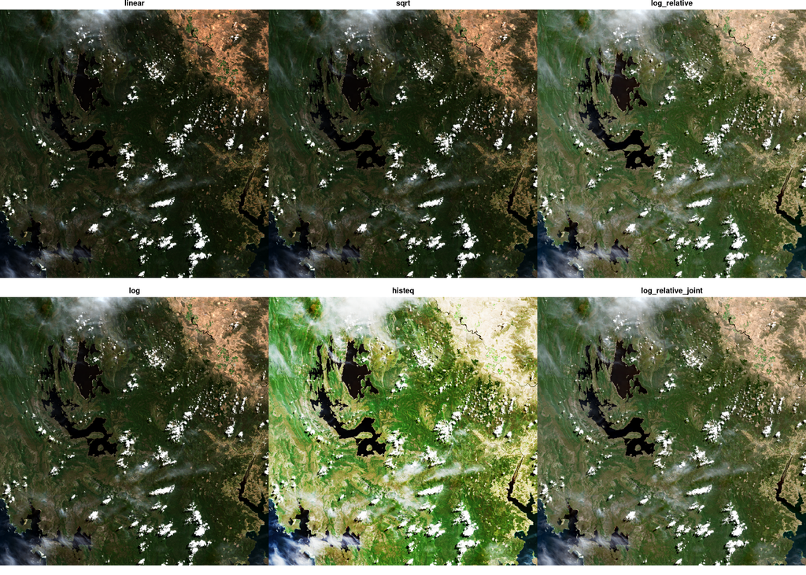

```r
library(terra)

band <- c("B04", "B03", "B02")
dsn  <- glue::glue("vrt:///vsicurl/https://e84-earth-search-sentinel-data.s3.us-west-2.amazonaws.com/sentinel-2-c1-l2a/55/G/DN/2026/2/S2C_T55GDN_20260227T000650_L2A/{band}.tif?ovr=2")
r    <- terra::rast(dsn)


mar <- par("mar")
op <- par(mfcol = c(2, 3), mar = mar + c(1, 0, 1, 0) * 2)
pltrgb(s2_stretch(r, "linear"),                       main = "linear")
pltrgb(s2_stretch(r, "log"),                          main = "log")
pltrgb(s2_stretch(r, "sqrt"),                         main = "sqrt")
pltrgb(s2_stretch(r, "histeq"),                       main = "histeq")
pltrgb(s2_stretch(r, "log_relative", joint = FALSE),  main = "log_relative")
pltrgb(s2_stretch(r, "log_relative"),                 main = "log_relative_joint")
```

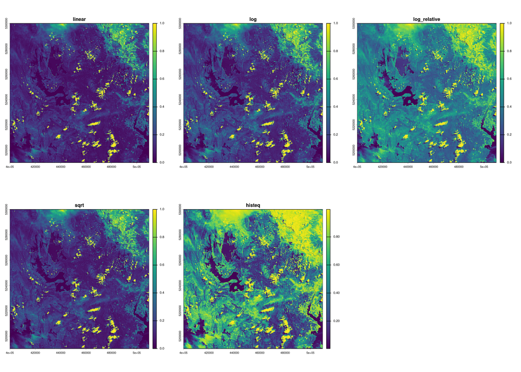

```r
par(op)
band <- "B04"
dsn  <- glue::glue("vrt:///vsicurl/https://e84-earth-search-sentinel-data.s3.us-west-2.amazonaws.com/sentinel-2-c1-l2a/55/G/DN/2026/2/S2C_T55GDN_20260227T000650_L2A/{band}.tif?ovr=2")
r    <- terra::rast(dsn)

par(mfcol = c(2, 3))
terra::plot(s2_stretch(r, "linear"),       main = "linear")
terra::plot(s2_stretch(r, "sqrt"),         main = "sqrt")
terra::plot(s2_stretch(r, "log"),          main = "log")
terra::plot(s2_stretch(r, "histeq"),       main = "histeq")
terra::plot(s2_stretch(r, "log_relative"), main = "log_relative")
```

## What the comparisons showed

### Single band (red, tile 55GDN, 2026-02-27)

[output not shown]

### RGB (B04/B03/B02 true colour)

[output not shown]

### Rules of thumb

- **Single band / false colour:** per-band stretch is fine; `log_relative` recommended
- **True colour RGB:** `joint = TRUE` (the default); `log_relative` is the sweet spot
- **Cloudy or snowy scenes:** tighten `high` to e.g. `0.90` to stop bright surfaces blowing out

## The terra/overview scaling gotcha

When terra reads Sentinel-2 at **native resolution** it applies the stored scale/offset metadata (typically ÷ 10000), yielding reflectance values < 1. Log transforms behave very differently at this scale — `log(0.03)` is strongly negative — and the minimum-subtraction approach doesn’t rescue it the same way.

When reading an **overview** (a lower-resolution pyramid level) the raw integers are returned as-is (values in the thousands), so log works naturally. Always check which regime you’re in:

```r
terra::scoff(r)  # scale, offset stored in file metadata; scale != 1 means reflectance
```

Reading overview level 2 explicitly via a VRT [vrt:// connection string](https://gdal.org/en/stable/drivers/raster/vrt.html#vrt-connection-string):

```r
dsn <- "vrt:///vsicurl/https://.../B04.tif?ovr=2"
r   <- terra::rast(dsn)
```